# Predicting Refund Requests in Indian E-Commerce Deliveries

## Phase 1: Data Preparation, Exploration & Visualization

**Group ID:** 7  
**Team Members:**

- Saurabh Sharma *(s4038560)*
- Shivam Shinde *(s3994666)*

### Introduction

1. Dataset Source
2. Dataset Overview
3. Dataset Retrieval
4. Dataset Features
5. Target Feature

### Goals & Objectives

### Literature Review: Refund Prediction in E-Commerce using Machine Learning

### Data Cleaning & Preprocessing

1. Handling Missing Values
2. Dropping Irrelevant Columns
3. Random Sampling
4. Encoding Binary (Yes/No) Features
5. Outlier Detection & Treatment
6. Exporting Cleaned Dataset

### Data Exploration & Visualization

#### One-Variable Plots

- Histogram of Order Value Distribution
- Boxplot of Order Value (Q1, Q3, IQR)
- Boxplot of Delivery Time (Minutes)
- Count of Product Categories

#### Three-Variable Plots

- Refund Count by Platform and Product Category
- Order Value vs Service Rating Colored by Refund Requested
- Delivery Time by Product Category and Refund Status (with IQR)

#### Additional Visuals

- Correlation Heatmap of Numeric Features

### Summary & Conclusions

### Introduction

This project explores **refund behavior in Indian e-commerce grocery delivery services**, using a simulated dataset that captures real-world characteristics of platforms like **Blinkit**, **Swiggy Instamart**, and **JioMart**. The dataset includes detailed information such as:

The **primary objective** is to build a **supervised classification model** in Phase 2 that can accurately **predict whether a customer will request a refund** for a given order.

### Phase 1 Scope

In this initial phase, we focused on:

- **Cleaning and preprocessing** the dataset (handling missing values, dropping ID-like columns, correcting time formats, etc.)
- **Feature engineering**, including transformation of time values and binary encoding
- **Outlier detection and treatment** for numerical columns like `Order Value` and `Delivery Time`
- Generating **statistical summaries** and **visualizations** to understand patterns related to refund behavior

These tasks form the analytical groundwork for model development in **Phase 2**, where predictive techniques will be applied and evaluated.

### Dataset Source

The dataset used in this project is publicly available on **Kaggle**, titled  
*“E-Commerce Analytics: Swiggy, Zomato, Blinkit”*, published by **LogicCraft by Himanshi**.

It simulates **real-world delivery patterns and customer behavior** across major Indian quick-commerce platforms, including:

- **Swiggy Instamart**
- **Blinkit**
- **JioMart**

The dataset is ideal for analyzing customer satisfaction, delivery performance, and refund behavior — all of which align with the project’s predictive goals.

[Access Dataset on Kaggle](https://www.kaggle.com/datasets/logiccraftbyhimanshi/e-commerce-analytics-swiggy-zomato-blinkit)

### Dataset Details

The original dataset used in this project, titled **`Ecommerce_Delivery_Analytics.csv`**, consists of **100,000 rows** and **11 features**, simulating e-commerce delivery data from leading Indian quick-commerce platforms including **Swiggy Instamart**, **JioMart**, and **Blinkit**.

Each row represents a **unique customer order**, capturing key attributes such as:

To ensure efficient computation while maintaining statistical integrity, a **random sample of 5,000 rows** was selected for analysis. This sample preserves the original data's diversity and distribution, making it suitable for exploratory analysis and predictive modeling.

### Dataset Retrieval

### Incorporating as per Canvas Instructions

```python
#Supress Warnings
import warnings
warnings.filterwarnings("ignore")
```

```python
#Importing required libraries
import pandas as pd
import numpy as np
```

```python
#Setting Random seed for reproducibility
import os
import random
seed_value=999
os.environ['PYTHONHASHSEED'] = str(seed_value)
random.seed(seed_value)
np.random.seed(seed_value)
```

```python
#Ensuring full column visibility
pd.set_option('display.max_columns', None)
```

### Loading Dataset

```python
#Loading the dataset
df=pd.read_csv("Ecommerce_Delivery_Analytics.csv")
```

```python
#Displaying the first ten rows of the dataset
display(df.head(10))
df.shape
```

|  | Order ID | Customer ID | Platform | Order Date & Time | Delivery Time (Minutes) | Product Category | Order Value (INR) | Customer Feedback | Service Rating | Delivery Delay | Refund Requested |
| --- | --- | --- | --- | --- | --- | --- | --- | --- | --- | --- | --- |
| 0 | ORD000001 | CUST2824 | JioMart | 19:29.5 | 30 | Fruits & Vegetables | 382 | Fast delivery, great service! | 5 | No | No |
| 1 | ORD000002 | CUST1409 | Blinkit | 54:29.5 | 16 | Dairy | 279 | Quick and reliable! | 5 | No | No |
| 2 | ORD000003 | CUST5506 | JioMart | 21:29.5 | 25 | Beverages | 599 | Items missing from order. | 2 | No | Yes |
| 3 | ORD000004 | CUST5012 | JioMart | 19:29.5 | 42 | Beverages | 946 | Items missing from order. | 2 | Yes | Yes |
| 4 | ORD000005 | CUST4657 | Blinkit | 49:29.5 | 30 | Beverages | 334 | Fast delivery, great service! | 5 | No | No |
| 5 | ORD000006 | CUST3286 | Blinkit | 36:29.5 | 25 | Personal Care | 1939 | Items missing from order. | 2 | No | Yes |
| 6 | ORD000007 | CUST2679 | JioMart | 22:29.5 | 22 | Personal Care | 1693 | Fast delivery, great service! | 5 | No | No |
| 7 | ORD000008 | CUST9935 | Swiggy Instamart | 50:29.5 | 16 | Personal Care | 195 | Horrible experience, never ordering again. | 1 | No | Yes |
| 8 | ORD000009 | CUST2424 | JioMart | 51:29.5 | 39 | Fruits & Vegetables | 182 | Very satisfied with the service. | 5 | No | No |
| 9 | ORD000010 | CUST7912 | JioMart | 08:29.5 | 51 | Grocery | 1279 | Very late delivery, not happy. | 2 | Yes | Yes |

```
(100000, 11)
```

```python
# Checking data types
display(df.dtypes)
```

```
Order ID                   object
Customer ID                object
Platform                   object
Order Date & Time          object
Delivery Time (Minutes)     int64
Product Category           object
Order Value (INR)           int64
Customer Feedback          object
Service Rating              int64
Delivery Delay             object
Refund Requested           object
dtype: object
```

```python
# Summary of categorical features
df.describe(include = 'object').T
```

|  | count | unique | top | freq |
| --- | --- | --- | --- | --- |
| Order ID | 100000 | 100000 | ORD000001 | 1 |
| Customer ID | 100000 | 9000 | CUST8779 | 26 |
| Platform | 100000 | 3 | Swiggy Instamart | 33449 |
| Order Date & Time | 100000 | 60 | 50:29.5 | 1755 |
| Product Category | 100000 | 6 | Dairy | 16857 |
| Customer Feedback | 100000 | 13 | Easy to order, loved it! | 7791 |
| Delivery Delay | 100000 | 2 | No | 86328 |
| Refund Requested | 100000 | 2 | No | 54181 |

These initial insights help in understanding user behavior and preparing relevant features for downstream predictive modeling tasks.

```python
# Summary of numeric features
df.describe(include = 'int64').T
```

|  | count | mean | std | min | 25% | 50% | 75% | max |
| --- | --- | --- | --- | --- | --- | --- | --- | --- |
| Delivery Time (Minutes) | 100000.0 | 29.53614 | 9.958933 | 5.0 | 23.0 | 30.0 | 36.0 | 76.0 |
| Order Value (INR) | 100000.0 | 590.99440 | 417.409058 | 50.0 | 283.0 | 481.0 | 770.0 | 2000.0 |
| Service Rating | 100000.0 | 3.24079 | 1.575962 | 1.0 | 2.0 | 3.0 | 5.0 | 5.0 |

These observations guide feature engineering decisions and inform the selection of appropriate modeling techniques in the next phase.

### Dataset Features

In accordance with the project guidelines, the feature table below includes only those variables that are relevant for analysis and predictive modeling in **Phase 2**.

Features such as **`Order ID`** and **`Customer ID`** were intentionally excluded, as they are **ID-like columns** that serve only as unique identifiers and offer no predictive value. These were dropped during the data cleaning process.

The final set of features was selected based on their **business relevance** and **potential influence on refund behavior**, including operational metrics (e.g., delivery time), customer responses (e.g., service rating), and order-level details (e.g., order value, platform, category).

This refined subset forms the basis for both **exploratory analysis in Phase 1** and **model training in Phase 2**.

```python
from tabulate import tabulate

# Feature Table
feature_table = [
    ['Name', 'Data Type', 'Units','Brief Description'],
    ['Platform', 'Nominal Categorical', 'NA', 'Platform used for ordering'],
    ['Order Date & Time', 'Nominal Categorical', 'Minutes', 'Timestamp when the order was placed'],
    ['Delivery Time (Minutes)', 'Numeric', 'Minutes', 'Time taken to deliver the order'],
    ['Product Category', 'Nominal Categorical', 'NA', 'Category of the product ordered'],
    ['Order Value (INR)', 'Numeric', 'INR', 'Total value of the order in Indian Rupees'],
    ['Customer Feedback', 'Nominal Categorical', 'NA', 'Free-text feedback from the customer'],
    ['Service Rating', 'Ordinal Categorical', 'Rating (1-5)', 'Rating given by customer for service quality'],
    ['Delivery Delay', 'Binary', 'NA', 'Whether the delivery was delayed (Yes/No)'],
    ['Refund Requested', 'Binary (Target)', 'NA', 'Whether the customer requested a refund (Yes/No)']
]

# Display as a grid table
print(tabulate(feature_table, headers='firstrow', tablefmt='fancy_grid'))
```

```
╒═════════════════════════╤═════════════════════╤══════════════╤══════════════════════════════════════════════════╕
│ Name                    │ Data Type           │ Units        │ Brief Description                                │
╞═════════════════════════╪═════════════════════╪══════════════╪══════════════════════════════════════════════════╡
│ Platform                │ Nominal Categorical │ NA           │ Platform used for ordering                       │
├─────────────────────────┼─────────────────────┼──────────────┼──────────────────────────────────────────────────┤
│ Order Date & Time       │ Nominal Categorical │ Minutes      │ Timestamp when the order was placed              │
├─────────────────────────┼─────────────────────┼──────────────┼──────────────────────────────────────────────────┤
│ Delivery Time (Minutes) │ Numeric             │ Minutes      │ Time taken to deliver the order                  │
├─────────────────────────┼─────────────────────┼──────────────┼──────────────────────────────────────────────────┤
│ Product Category        │ Nominal Categorical │ NA           │ Category of the product ordered                  │
├─────────────────────────┼─────────────────────┼──────────────┼──────────────────────────────────────────────────┤
│ Order Value (INR)       │ Numeric             │ INR          │ Total value of the order in Indian Rupees        │
├─────────────────────────┼─────────────────────┼──────────────┼──────────────────────────────────────────────────┤
│ Customer Feedback       │ Nominal Categorical │ NA           │ Free-text feedback from the customer             │
├─────────────────────────┼─────────────────────┼──────────────┼──────────────────────────────────────────────────┤
│ Service Rating          │ Ordinal Categorical │ Rating (1-5) │ Rating given by customer for service quality     │
├─────────────────────────┼─────────────────────┼──────────────┼──────────────────────────────────────────────────┤
│ Delivery Delay          │ Binary              │ NA           │ Whether the delivery was delayed (Yes/No)        │
├─────────────────────────┼─────────────────────┼──────────────┼──────────────────────────────────────────────────┤
│ Refund Requested        │ Binary (Target)     │ NA           │ Whether the customer requested a refund (Yes/No) │
╘═════════════════════════╧═════════════════════╧══════════════╧══════════════════════════════════════════════════╛
```

### Target Feature

The target variable for this project is **`Refund Requested`**, which indicates whether a customer **requested a refund** for a specific order.

This is a **binary categorical variable**, with the following values:

- **1** → Refund was requested (**Yes**)
- **0** → No refund was requested (**No**)

This feature acts as the **output variable** for the binary classification model to be developed in **Phase 2**. The objective is to use relevant input features (such as delivery performance, order value, and service rating) to **predict the likelihood of a refund request**, enabling proactive interventions to minimize refund-related losses.

### Goals and Objectives

The **overall goal** of this project is to develop a machine learning model that can accurately **predict whether a customer will request a refund**, using data available at the time of order and delivery. This has significant real-world value for e-commerce platforms, as refund requests often reflect **customer dissatisfaction**, **delivery issues**, and **potential financial losses**.

### Phase 1 Objectives – Data Exploration & Preparation

The focus of **Phase 1** is to lay a solid foundation for predictive modeling by:

- Conducting comprehensive **data cleaning and preprocessing** (handling missing values, correcting data types, and treating outliers)
- Performing **exploratory data analysis (EDA)** to uncover trends, relationships, and anomalies
- **Encoding features** appropriately and identifying those most relevant for prediction
- Creating informative **visualizations** that highlight key patterns (e.g., refund behavior by platform or product category)
- Preparing a clean and well-structured dataset for model development in Phase 2

### Phase 2 Objectives – Predictive Modeling

The upcoming **Phase 2** will focus on building and evaluating classification models to:

- Identify the **key drivers** influencing refund behavior (e.g., delivery delay, service rating, order value)
- **Evaluate and compare** multiple machine learning models using appropriate metrics such as **accuracy, precision, recall, and F1-score**
- Build a model that is both **predictively strong and interpretable**, suitable for real-time deployment in customer service systems
- Deliver **actionable business insights** to help e-commerce platforms reduce refund rates and enhance overall customer experience

### Literature Review: Refund Prediction in E-Commerce using Machine Learning

In the fast-evolving landscape of e-commerce, refund prediction has become increasingly important due to its direct connection with customer satisfaction, financial performance, and operational efficiency. The application of machine learning to forecast refund requests can enable businesses to proactively mitigate customer dissatisfaction, improve logistics, and reduce the costs associated with returns and complaints. This literature review explores recent studies and developments in this domain, focusing on the intersection of machine learning, customer behavior analysis, and refund modeling in online retail.

#### E-commerce and Customer Return Behavior

Customer refund behavior has been studied extensively in e-commerce literature. A key insight comes from the work of Hong et al. (2020), who demonstrated how customer transaction history, delivery times, and satisfaction ratings can predict returns with high accuracy. They used logistic regression and decision tree classifiers on historical return datasets and found that late delivery, poor packaging, and mismatch between product description and reality are strong indicators of refund probability.

#### Importance of Delivery Performance

Delivery delays are one of the most cited reasons for refunds and dissatisfaction. Research by Lee & Yu (2019) found that integrating delivery performance metrics (e.g., on-time delivery, delivery distance, service rating) into predictive models significantly improves refund forecasting accuracy. Their model combined Support Vector Machines (SVM) with Random Forests and achieved over 80% accuracy on a large Korean e-commerce dataset.

#### Sentiment Analysis and Customer Feedback

Another influential study by Medhat et al. (2014) reviewed the effectiveness of sentiment analysis in predicting product return behavior. Analyzing customer feedback through Natural Language Processing (NLP) techniques provides valuable insights into dissatisfaction that may not be visible through numerical ratings. Modern techniques such as BERT and LSTM-based models have shown promising results in classifying refund-intent through customer reviews.

#### Machine Learning Algorithms for Classification

Recent comparative studies have explored different algorithms for classification tasks involving binary outcomes such as refunds. For example, Wang et al. (2021) evaluated several supervised learning techniques—Random Forest, XGBoost, Logistic Regression, and Neural Networks—on Alibaba's e-commerce return dataset. XGBoost outperformed others in precision and recall due to its ability to capture non-linear interactions between features like payment method, product category, and delivery duration.

#### Data Challenges in Refund Prediction

Refund prediction in e-commerce faces persistent challenges related to data quality, class imbalance and limited labeled examples. Real world datasets are often skewed, with refund cases forming a small proportion, making accurate modeling difficult. He and Garcia (2009) highlight that such imbalance can cause classifiers to favour the majority class, overlooking critical refund cases. Buda et al (2018) further demonstrated that imbalance can reduce generalization in deep learning models. Noisy or incomplete transaction records also undermine model performance, as shown by Vatsalan et al (2013), who emphasized the risks of poor data linkage. In multiclass refund scenarios - e.g., by platform or product category - Wang and Yao (2013) note that imbalance intensifies, requiring more granular handling. To mitigate these issues, advanced techniques such as generative oversampling (Hayaeian Shrivan et al., 2025) and robust ensemble models like XGBoost (Chen & Guestrin, 2016) have been adopted. Yet, as Chen et al. (2024) observe, no single method universally solves imbalance, reinforcing the need for tailored approaches in refund modeling.

#### Feature Importance and Explainability

Interpreting model predictions is crucial for e-commerce managers. Ribeiro et al. (2016) introduced LIME (Local Interpretable Model-Agnostic Explanations), which allows understanding individual predictions, especially useful in refund prediction where human decisions still influence outcomes. Shapley values (SHAP) have also gained popularity in highlighting which features (e.g., discount applied, delivery charges) drive refund requests the most.

#### Domain-Specific Applications

In Indian e-commerce, where platforms like Swiggy Instamart, Blinkit, and JioMart dominate the quick-commerce segment, limited literature exists on refund prediction. However, Kumar et al. (2022) highlighted that Indian consumers are highly price-sensitive, and refund behavior is often tied to discount expectation, failed delivery promises, and product category. Their research using clustering and supervised models revealed that personal care and electronics had the highest refund rates.

#### Research Gap and Our Contribution

While existing studies have laid the foundation for refund prediction using ML, few studies explore refund forecasting in the context of **Indian quick-commerce platforms** with a combined emphasis on delivery time, service rating, and platform-specific dynamics. Our study contributes by applying machine learning techniques to simulate refund behavior in this domain using a real-world inspired dataset. We also integrate platform-wise and category-wise analysis with predictive modeling and visualization, creating a holistic view of refund tendencies in a rapidly growing market.

### Data Cleaning and Preprocessing

- Check for missing values
- Dropping irrelevant features in the dataset
- Check and rename/modify some column names
- Random sampling of the dataset for 5000 rows
- Resetting the index
- Encoding binary (Yes/No) features
- Check for outliers

### Missing Values

```python
#Checking for missing values
df.isnull().sum()
```

```
Order ID                   0
Customer ID                0
Platform                   0
Order Date & Time          0
Delivery Time (Minutes)    0
Product Category           0
Order Value (INR)          0
Customer Feedback          0
Service Rating             0
Delivery Delay             0
Refund Requested           0
dtype: int64
```

### Dropping columns

```python
#Dropping ID like columns
df.drop(columns=["Order ID", "Customer ID"], inplace=True)
df.head(10)
```

|  | Platform | Order Date & Time | Delivery Time (Minutes) | Product Category | Order Value (INR) | Customer Feedback | Service Rating | Delivery Delay | Refund Requested |
| --- | --- | --- | --- | --- | --- | --- | --- | --- | --- |
| 0 | JioMart | 19:29.5 | 30 | Fruits & Vegetables | 382 | Fast delivery, great service! | 5 | No | No |
| 1 | Blinkit | 54:29.5 | 16 | Dairy | 279 | Quick and reliable! | 5 | No | No |
| 2 | JioMart | 21:29.5 | 25 | Beverages | 599 | Items missing from order. | 2 | No | Yes |
| 3 | JioMart | 19:29.5 | 42 | Beverages | 946 | Items missing from order. | 2 | Yes | Yes |
| 4 | Blinkit | 49:29.5 | 30 | Beverages | 334 | Fast delivery, great service! | 5 | No | No |
| 5 | Blinkit | 36:29.5 | 25 | Personal Care | 1939 | Items missing from order. | 2 | No | Yes |
| 6 | JioMart | 22:29.5 | 22 | Personal Care | 1693 | Fast delivery, great service! | 5 | No | No |
| 7 | Swiggy Instamart | 50:29.5 | 16 | Personal Care | 195 | Horrible experience, never ordering again. | 1 | No | Yes |
| 8 | JioMart | 51:29.5 | 39 | Fruits & Vegetables | 182 | Very satisfied with the service. | 5 | No | No |
| 9 | JioMart | 08:29.5 | 51 | Grocery | 1279 | Very late delivery, not happy. | 2 | Yes | Yes |

```python
#Remaning column 'Order Date & Time'
df.rename(columns={'Order Date & Time': 'Order Time'}, inplace=True)
```

```python
#Extracting hour and minute
df['Order Hour'] = df['Order Time'].str.split(":").str[0].astype(int)
df['Order Minute'] = df['Order Time'].str.split(":").str[1].astype(float)

#Combining into a single time feature
df['Order Time(Minutes)'] = df['Order Hour'] *60 + df['Order Minute']
```

```python
df.drop(columns=["Order Time", "Order Hour", "Order Minute"], inplace=True)  #Dropping columns
df.head(10)
```

|  | Platform | Delivery Time (Minutes) | Product Category | Order Value (INR) | Customer Feedback | Service Rating | Delivery Delay | Refund Requested | Order Time(Minutes) |
| --- | --- | --- | --- | --- | --- | --- | --- | --- | --- |
| 0 | JioMart | 30 | Fruits & Vegetables | 382 | Fast delivery, great service! | 5 | No | No | 1169.5 |
| 1 | Blinkit | 16 | Dairy | 279 | Quick and reliable! | 5 | No | No | 3269.5 |
| 2 | JioMart | 25 | Beverages | 599 | Items missing from order. | 2 | No | Yes | 1289.5 |
| 3 | JioMart | 42 | Beverages | 946 | Items missing from order. | 2 | Yes | Yes | 1169.5 |
| 4 | Blinkit | 30 | Beverages | 334 | Fast delivery, great service! | 5 | No | No | 2969.5 |
| 5 | Blinkit | 25 | Personal Care | 1939 | Items missing from order. | 2 | No | Yes | 2189.5 |
| 6 | JioMart | 22 | Personal Care | 1693 | Fast delivery, great service! | 5 | No | No | 1349.5 |
| 7 | Swiggy Instamart | 16 | Personal Care | 195 | Horrible experience, never ordering again. | 1 | No | Yes | 3029.5 |
| 8 | JioMart | 39 | Fruits & Vegetables | 182 | Very satisfied with the service. | 5 | No | No | 3089.5 |
| 9 | JioMart | 51 | Grocery | 1279 | Very late delivery, not happy. | 2 | Yes | Yes | 509.5 |

### Random Sampling

```python
#Random Sampling (limit to 5000 to reduce size)
df=df.sample(n=5000, random_state=999)
df.shape
display(df.head(10))
```

|  | Platform | Delivery Time (Minutes) | Product Category | Order Value (INR) | Customer Feedback | Service Rating | Delivery Delay | Refund Requested | Order Time(Minutes) |
| --- | --- | --- | --- | --- | --- | --- | --- | --- | --- |
| 11588 | JioMart | 15 | Beverages | 754 | Good quality products. | 4 | No | No | 2969.5 |
| 43662 | JioMart | 47 | Personal Care | 1848 | Packaging could be better. | 3 | Yes | No | 3389.5 |
| 6448 | Swiggy Instamart | 32 | Grocery | 865 | Quick and reliable! | 5 | No | No | 989.5 |
| 69042 | Swiggy Instamart | 31 | Beverages | 402 | Excellent experience! | 5 | No | No | 2969.5 |
| 30657 | Swiggy Instamart | 29 | Fruits & Vegetables | 529 | Wrong item delivered. | 1 | No | Yes | 389.5 |
| 57708 | JioMart | 27 | Personal Care | 1386 | Good quality products. | 4 | No | No | 2189.5 |
| 99182 | Swiggy Instamart | 19 | Grocery | 1255 | Fast delivery, great service! | 5 | No | No | 3149.5 |
| 92344 | Swiggy Instamart | 23 | Grocery | 997 | Very late delivery, not happy. | 2 | No | Yes | 1049.5 |
| 42497 | Swiggy Instamart | 17 | Fruits & Vegetables | 400 | Good quality products. | 4 | No | No | 569.5 |
| 8990 | JioMart | 31 | Snacks | 164 | Packaging could be better. | 3 | No | No | 2669.5 |

```python
#Resetting the index
df.reset_index(drop=True, inplace=True)
df.head(10)
```

|  | Platform | Delivery Time (Minutes) | Product Category | Order Value (INR) | Customer Feedback | Service Rating | Delivery Delay | Refund Requested | Order Time(Minutes) |
| --- | --- | --- | --- | --- | --- | --- | --- | --- | --- |
| 0 | JioMart | 15 | Beverages | 754 | Good quality products. | 4 | No | No | 2969.5 |
| 1 | JioMart | 47 | Personal Care | 1848 | Packaging could be better. | 3 | Yes | No | 3389.5 |
| 2 | Swiggy Instamart | 32 | Grocery | 865 | Quick and reliable! | 5 | No | No | 989.5 |
| 3 | Swiggy Instamart | 31 | Beverages | 402 | Excellent experience! | 5 | No | No | 2969.5 |
| 4 | Swiggy Instamart | 29 | Fruits & Vegetables | 529 | Wrong item delivered. | 1 | No | Yes | 389.5 |
| 5 | JioMart | 27 | Personal Care | 1386 | Good quality products. | 4 | No | No | 2189.5 |
| 6 | Swiggy Instamart | 19 | Grocery | 1255 | Fast delivery, great service! | 5 | No | No | 3149.5 |
| 7 | Swiggy Instamart | 23 | Grocery | 997 | Very late delivery, not happy. | 2 | No | Yes | 1049.5 |
| 8 | Swiggy Instamart | 17 | Fruits & Vegetables | 400 | Good quality products. | 4 | No | No | 569.5 |
| 9 | JioMart | 31 | Snacks | 164 | Packaging could be better. | 3 | No | No | 2669.5 |

### Encoding binary Yes/No features

```python
#Encoding binary Yes/No features without one-hot encoding as per assignment instructions
df['Delivery Delay'] = df['Delivery Delay'].map({'Yes': 1, "No": 0})
df['Refund Requested'] = df['Refund Requested'].map({'Yes': 1, "No": 0})
df.head(10)
```

|  | Platform | Delivery Time (Minutes) | Product Category | Order Value (INR) | Customer Feedback | Service Rating | Delivery Delay | Refund Requested | Order Time(Minutes) |
| --- | --- | --- | --- | --- | --- | --- | --- | --- | --- |
| 0 | JioMart | 15 | Beverages | 754 | Good quality products. | 4 | 0 | 0 | 2969.5 |
| 1 | JioMart | 47 | Personal Care | 1848 | Packaging could be better. | 3 | 1 | 0 | 3389.5 |
| 2 | Swiggy Instamart | 32 | Grocery | 865 | Quick and reliable! | 5 | 0 | 0 | 989.5 |
| 3 | Swiggy Instamart | 31 | Beverages | 402 | Excellent experience! | 5 | 0 | 0 | 2969.5 |
| 4 | Swiggy Instamart | 29 | Fruits & Vegetables | 529 | Wrong item delivered. | 1 | 0 | 1 | 389.5 |
| 5 | JioMart | 27 | Personal Care | 1386 | Good quality products. | 4 | 0 | 0 | 2189.5 |
| 6 | Swiggy Instamart | 19 | Grocery | 1255 | Fast delivery, great service! | 5 | 0 | 0 | 3149.5 |
| 7 | Swiggy Instamart | 23 | Grocery | 997 | Very late delivery, not happy. | 2 | 0 | 1 | 1049.5 |
| 8 | Swiggy Instamart | 17 | Fruits & Vegetables | 400 | Good quality products. | 4 | 0 | 0 | 569.5 |
| 9 | JioMart | 31 | Snacks | 164 | Packaging could be better. | 3 | 0 | 0 | 2669.5 |

### Outliers

```python
#Handling Outliers with clamp function
def clamp(series, lower_percentile=1, upper_percentile=99):
    lower = np.percentile(series, lower_percentile)
    upper = np.percentile(series, upper_percentile)
    print(f"{series.name} Clamping Outliers to Range: [{round(lower,2)} - {round(upper,2)}]")
    return np.clip(series, lower, upper)

numeric_cols = ['Delivery Time (Minutes)', 'Order Value (INR)', 'Service Rating']
for col in numeric_cols:
    df[col] = clamp(df[col])
```

```
Delivery Time (Minutes) Clamping Outliers to Range: [7.0 - 54.0]
Order Value (INR) Clamping Outliers to Range: [66.99 - 1903.01]
Service Rating Clamping Outliers to Range: [1.0 - 5.0]
```

```python
#Checking for any values that are still outside the above ranges
clamp_bounds = {
    'Delivery Time (Minutes)': (7.0, 54.0),
    'Order Value (INR)': (66.99, 1903.01),
    'Service Rating': (1.0,5.0)
}
for col, (low,high) in clamp_bounds.items():
    below = df[df[col] < low].shape[0]
    above = df[df[col] > high].shape[0]
    print(f"{col}: Values < {low} = {below}, Values > {high} = {above}")
```

```
Delivery Time (Minutes): Values < 7.0 = 0, Values > 54.0 = 0
Order Value (INR): Values < 66.99 = 0, Values > 1903.01 = 50
Service Rating: Values < 1.0 = 0, Values > 5.0 = 0
```

### Boxplot Interpretation

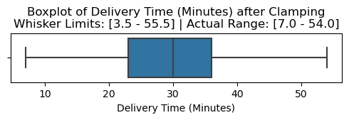

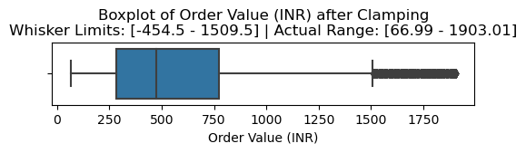

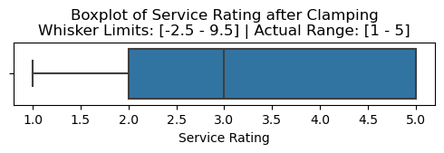

```python
#Visual Check of outliers with boxplot
import seaborn as sns
import matplotlib.pyplot as plt

#Loop through each numeric column
for col in numeric_cols:
    Q1 = df[col].quantile(0.25) #Calculating whisker limits using IQR method
    Q3 = df[col].quantile(0.75)
    IQR = Q3-Q1
    lower_whisker = Q1 - 1.5*IQR
    upper_whisker = Q3 + 1.5*IQR

    actual_min = df[col].min() #Actual min and max values from data after clamping
    actual_max = df[col].max()


    plt.figure(figsize=(5,1.8)) #Plotting boxplot
    sns.boxplot(x=df[col])
    plt.title(
        f"Boxplot of {col} after Clamping\n"
        f"Whisker Limits: [{round(lower_whisker, 2)} - {round(upper_whisker, 2)}] | "
        f"Actual Range: [{round(actual_min, 2)} - {round(actual_max, 2)}]"
    )
    plt.xlabel(col)
    plt.tight_layout()
    plt.show()
```

The boxplots generated for **Order Value (INR)** and **Service Rating** offer important insights into data distribution and outliers, especially after applying percentile-based clamping:

These nuances reinforce the importance of understanding **the difference between clamping thresholds and statistical outlier detection**, especially when preparing data for machine learning models.

### Saving Cleaned Dataset

```python
#Saving the cleaned dataframe to CSV
df.to_csv("Phase1_Group7.csv", index=False)
```

## Data Exploration and Visualization

### One-Variable Plots

```python
#Loading cleaned dataset
df_cleaned = pd.read_csv("Phase1_Group7.csv")
```

### 1. Order Value Distribution

```python
#Setting seaborn style and default figure size for consistent and clean visuals
sns.set(style="whitegrid")
plt.rcParams["figure.figsize"] = (8,5)
```

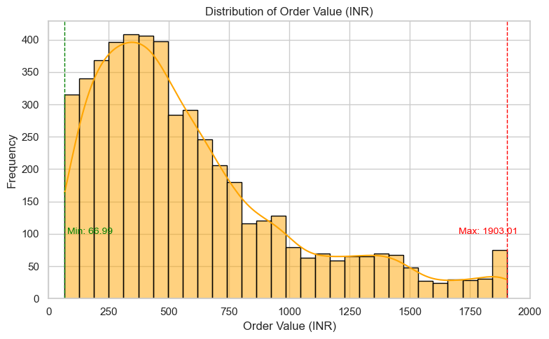

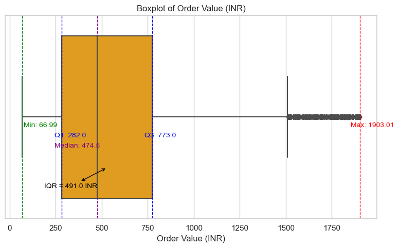

```python
#Getting min and max order values
min_val = df_cleaned["Order Value (INR)"].min()
max_val = df_cleaned["Order Value (INR)"].max()

plt.figure()
sns.histplot(df_cleaned['Order Value (INR)'], bins=30, kde=True, color='orange', edgecolor='black')
plt.title("Distribution of Order Value (INR)")
plt.xlabel("Order Value (INR)")
plt.ylabel("Frequency")
plt.xlim(0,2000)

#Annotate min value
plt.axvline(min_val, color='green', linestyle='--', linewidth='1.0')
plt.text(min_val +10, 100, f"Min: {round(min_val, 2)}", color='green', fontsize=10)

#Annotate max value
plt.axvline(max_val, color='red', linestyle='--', linewidth='1.0')
plt.text(max_val -200, 100, f"Max: {round(max_val, 2)}", color='red', fontsize=10)

plt.tight_layout()
plt.show()

# Boxplot of Order Value to understand refund prone high value outliers

#Getting median and quartile values
q1 = df_cleaned["Order Value (INR)"].quantile(0.25)
median = df_cleaned["Order Value (INR)"].median()
q3 = df_cleaned["Order Value (INR)"].quantile(0.75)
iqr=q3-q1

plt.figure()
sns.boxplot(x = "Order Value (INR)", data = df_cleaned, color='orange')
plt.title("Boxplot of Order Value (INR)")
plt.xlabel("Order Value (INR)")

#Annotate min value
plt.axvline(min_val, color='green', linestyle='--', linewidth='1.0')
plt.text(min_val + 10, 0.05, f"Min: {round(min_val, 2)}", color='green', fontsize=10)

#Annotate median and quantile values
plt.axvline(q1, color='blue', linestyle='--', linewidth='1.0')
plt.text(q1 - 40, 0.1, f"Q1: {round(q1, 2)}", color='blue', fontsize=10)

plt.axvline(median, color='purple', linestyle='--', linewidth='1.0')
plt.text(q1 - 40, 0.15, f"Median: {round(median, 2)}", color='purple', fontsize=10)

plt.axvline(q3, color='blue', linestyle='--', linewidth='1.0')
plt.text(q3 - 40, 0.1, f"Q3: {round(q3, 2)}", color='blue', fontsize=10)

#Annotate max value
plt.axvline(max_val, color='red', linestyle='--', linewidth='1.0')
plt.text(max_val - 50, 0.05, f"Max: {round(max_val, 2)}", color='red', fontsize=10)

#Annotate IQR span
plt.annotate(f"IQR = {iqr:.1f} INR",
             xy = ((q1 + q3)/2, 0.25), xytext = (q1 +50, 0.35),
             arrowprops = dict(arrowstyle = '<->', color = 'black'),
             ha = 'center', fontsize = 10, color = 'black')

plt.tight_layout()
plt.show()
```

The **histogram** illustrates the distribution of order values across all transactions. A clear concentration of orders is observed between **₹200 and ₹600**, reflecting the typical spending range in quick-commerce. The **maximum order value**, ₹1903.01, indicates a few high-value purchases, while the **minimum**, ₹66.99, marks the lower bound after outlier clamping. The **KDE curve** confirms a **right-skewed distribution**, highlighting that high-value orders are relatively rare.

The accompanying **boxplot** provides a statistical summary of the same distribution. The **interquartile range (IQR)** spans approximately **₹491**, from **Q1 = ₹282** to **Q3 = ₹773**, with a **median order value** of **₹474.5**. The extended right whisker and the presence of outliers further reinforce the **positive skew**, suggesting that although most orders are moderately priced, a small number of significantly higher-value transactions extend the upper range.

These plots not only help in understanding user purchasing patterns but also assist in identifying potential **outlier behavior** that could influence predictive modeling.

### 2. Product Category Distribution

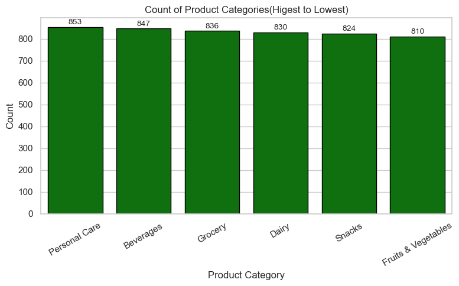

```python
#Sorting product category in descending order
sorted_order = df_cleaned['Product Category'].value_counts().sort_values(ascending=False).index

plt.figure()
ax = sns.countplot(x = "Product Category", data = df_cleaned, order = sorted_order, color='green', edgecolor='black')
plt.title("Count of Product Categories(Higest to Lowest)")
plt.xlabel("Product Category")
plt.ylabel("Count")
plt.xticks(rotation=30)

#Adding count labels on top of bars
for p in ax.patches:                      #Rectangular bar objects
             count = int(p.get_height())  #Height of the bar i.e. count
             #Label at the centre with horizontal and vertical alignment
             ax.annotate(str(count), (p.get_x() + p.get_width() / 2, p.get_height() + 5), ha='center', va='bottom', fontsize=10)
plt.tight_layout()
plt.show()
```

The bar plot illustrates the **frequency of orders across different product categories** in the dataset. **Personal Care** emerges as the most frequently ordered category (**853 orders**), while **Fruits & Vegetables** has the fewest (**810 orders**).

The relatively **even distribution** across all categories suggests a well-balanced dataset, minimizing the risk of model bias toward any single category. This balance is especially important in supervised learning, as it ensures that predictions related to refund behavior are not skewed by overrepresented classes.

Overall, this plot highlights **diverse consumer preferences** and supports the suitability of **Product Category** as a meaningful feature for modeling in Phase 2.

### 3. Delivery Time Distribution

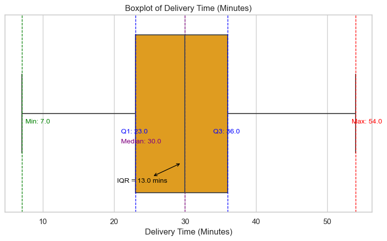

```python
#Getting min, max, median and quartile values
min_val = df_cleaned["Delivery Time (Minutes)"].min()
q1 = df_cleaned["Delivery Time (Minutes)"].quantile(0.25)
median = df_cleaned["Delivery Time (Minutes)"].median()
max_val = df_cleaned["Delivery Time (Minutes)"].max()
q3 = df_cleaned["Delivery Time (Minutes)"].quantile(0.75)
iqr=q3-q1

plt.figure()
sns.boxplot(x = "Delivery Time (Minutes)", data = df_cleaned, color='orange')
plt.title("Boxplot of Delivery Time (Minutes)")
plt.xlabel("Delivery Time (Minutes)")

#Annotate min value
plt.axvline(min_val, color='green', linestyle='--', linewidth='1.0')
plt.text(min_val + 0.5, 0.05, f"Min: {round(min_val, 2)}", color='green', fontsize=10)

#Annotate median and quantile values
plt.axvline(q1, color='blue', linestyle='--', linewidth='1.0')
plt.text(q1 - 2, 0.1, f"Q1: {round(q1, 2)}", color='blue', fontsize=10)

plt.axvline(median, color='purple', linestyle='--', linewidth='1.0')
plt.text(q1 - 2, 0.15, f"Median: {round(median, 2)}", color='purple', fontsize=10)

plt.axvline(q3, color='blue', linestyle='--', linewidth='1.0')
plt.text(q3 - 2, 0.1, f"Q3: {round(q3, 2)}", color='blue', fontsize=10)

#Annotate max value
plt.axvline(max_val, color='red', linestyle='--', linewidth='1.0')
plt.text(max_val - 0.5, 0.05, f"Max: {round(max_val, 2)}", color='red', fontsize=10)

#Annotate IQR span
plt.annotate(f"IQR = {iqr:.1f} mins",
             xy = ((q1 + q3)/2, 0.25), xytext = (q1 +1, 0.35),
             arrowprops = dict(arrowstyle = '<->', color = 'black'),
             ha = 'center', fontsize = 10, color = 'black')

plt.tight_layout()
plt.show()
```

This boxplot presents the distribution of **delivery times** across all e-commerce orders. The observed **minimum and maximum delivery times** are **7 minutes** and **54 minutes**, respectively.

The compact spread and symmetry around the median suggest a **stable and predictable delivery performance** across platforms and categories, which aligns with the expectations of quick-commerce services.

This insight also reinforces the potential importance of **delivery time** as a predictive feature for downstream modeling of refund behavior.

### Two Variable plots

### 1. Average Refund Rate by Platform (%)

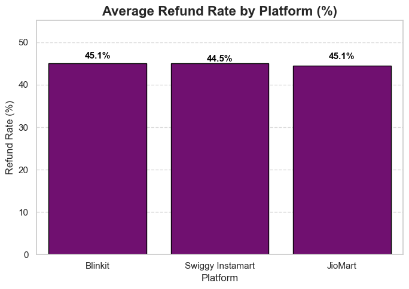

```python
import seaborn as sns
import matplotlib.pyplot as plt

# Recalculate refund rate per platform
refund_rate = df_cleaned.groupby('Platform')['Refund Requested'].mean().reset_index()
refund_rate['Refund Requested'] *= 100  # Convert to percentage
refund_rate = refund_rate.sort_values(by='Refund Requested', ascending=False)  # Sort descending

# Plot with detailed styling
plt.figure(figsize=(7,5))
ax = sns.barplot(
    x='Platform',
    y='Refund Requested',
    data=refund_rate,
    color ='purple',
    edgecolor='black'
)

# Add text labels on top of each bar
for index, row in refund_rate.iterrows():
    ax.text(index, row['Refund Requested'] + 1, f"{row['Refund Requested']:.1f}%",
            color='black', ha='center', fontsize=11, fontweight='bold')

# Enhancing titles and labels
plt.title('Average Refund Rate by Platform (%)', fontsize=16, fontweight='bold')
plt.xlabel('Platform', fontsize=12)
plt.ylabel('Refund Rate (%)', fontsize=12)
plt.ylim(0, refund_rate['Refund Requested'].max() + 10)
plt.grid(axis='y', linestyle='--', alpha=0.7)
plt.tight_layout()
plt.show()
```

This bar plot shows the **percentage of orders** that resulted in a **refund request**, grouped by platform. The refund rate is computed as:

**Refund Rate (%) = (Refund Requested Orders / Total Orders) × 100**

Although the differences are small, the overall refund rates (~45%) indicate that **nearly half of all orders lead to a refund request**, which can have **serious cost implications** for the business.

**Business Insight:**

- Reducing refund rates, even slightly, can lead to major savings and improved customer satisfaction.
- Platforms should investigate **common refund triggers** (e.g. delivery delays, product issues) and take proactive actions.

### 2. Count of Refund Requested Orders by Product Category

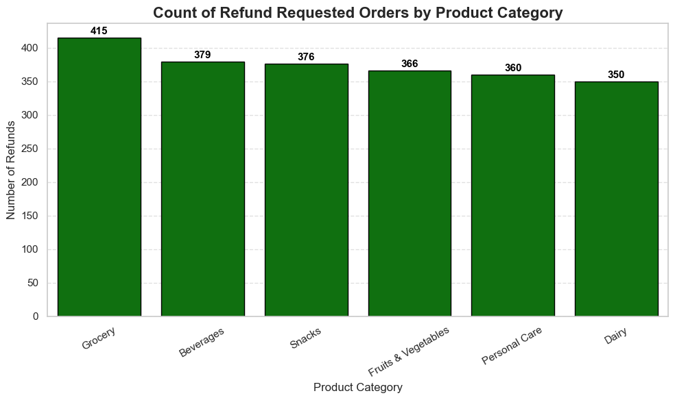

```python
# Filter for refund requested orders only
df_refunded = df_cleaned[df_cleaned['Refund Requested'] == 1]

# Plot aesthetically enhanced bar chart
plt.figure(figsize=(10,6))
ax = sns.countplot(
    x='Product Category',
    data=df_refunded,
    order=df_refunded['Product Category'].value_counts().index,
    color ='green',
    edgecolor='black'
)

# Add value labels on bars
for p in ax.patches:
    ax.annotate(f'{int(p.get_height())}',
                (p.get_x() + p.get_width() / 2., p.get_height() + 5),
                ha='center', fontsize=11, fontweight='bold', color='black')

# Style the plot
plt.title('Count of Refund Requested Orders by Product Category', fontsize=16, fontweight='bold')
plt.xlabel('Product Category', fontsize=12)
plt.ylabel('Number of Refunds', fontsize=12)
plt.xticks(rotation=30)
plt.grid(axis='y', linestyle='--', alpha=0.6)
plt.tight_layout()
plt.show()
```

This bar chart illustrates the **total number of refund requests** received for each product category across all platforms. **Grocery** leads with the highest number of refund requests (**415 orders**), followed by:

- **Beverages** (379)
- **Snacks** (376)
- **Fruits & Vegetables** (366)
- **Personal Care** (360)
- **Dairy** (350)

**Business Insight:**

- High refund volume in Grocery and Beverages categories may indicate issues like **spoilage, packaging errors, or delays**.
- These areas should be **audited for operational improvements** to reduce customer churn and financial loss.

### 3. Total Order Value of Refund Requested Orders by Product Category

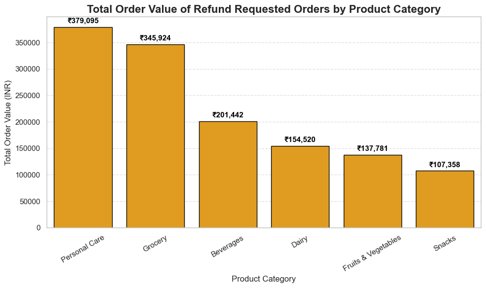

```python
# Filter for refund requested orders only
df_refunded = df_cleaned[df_cleaned['Refund Requested'] == 1]

# Group by product category and sum order values
refund_value_by_category = df_refunded.groupby('Product Category')['Order Value (INR)'].sum().reset_index()

# Sort for better visual clarity
refund_value_by_category = refund_value_by_category.sort_values(by='Order Value (INR)', ascending=False)

# Aesthetically improved plot
plt.figure(figsize=(10,6))
bars = sns.barplot(
    x='Product Category',
    y='Order Value (INR)',
    data=refund_value_by_category,
    color='orange',
    edgecolor='black'
)

# Add value labels with currency formatting
for p in bars.patches:
    value = int(p.get_height())
    bars.annotate(f'₹{value:,}',
                  (p.get_x() + p.get_width() / 2., value + 5000),
                  ha='center', va='bottom',
                  fontsize=11, fontweight='bold', color='black')

# Styling the chart
plt.title('Total Order Value of Refund Requested Orders by Product Category', fontsize=16, fontweight='bold')
plt.xlabel('Product Category', fontsize=12)
plt.ylabel('Total Order Value (INR)', fontsize=12)
plt.xticks(rotation=30)
plt.grid(axis='y', linestyle='--', alpha=0.6)
plt.tight_layout()
plt.show()
```

This chart visualizes the **aggregate monetary value (in INR)** of all orders for which a refund was requested, grouped by product category.

- **Personal Care** tops the list with refund requests totaling **₹379,095**, followed by:
  - **Grocery**: ₹345,924
  - **Beverages**: ₹201,442
  - **Dairy**: ₹154,520
  - **Fruits & Vegetables**: ₹137,781
  - **Snacks**: ₹107,358

**Note:** This reflects the **order value associated with refund requests**, not the actual refunded amount — as refund data is not available in the dataset.

**Business Insight:**

- Even though Grocery had the highest number of refund requests, **Personal Care** accounts for the highest refund-related order value, likely due to higher unit prices.
- This highlights the importance of **monitoring high-value categories** closely to reduce refund-related financial exposure.

### Three Variable Plots

### 1. Refund Count by Platform and Product Category

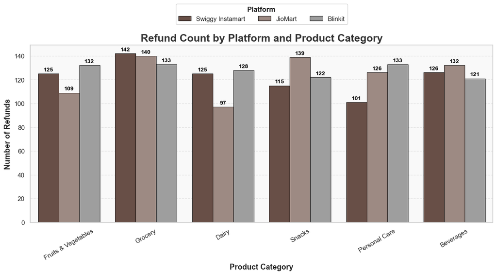

```python
# Filter for refund requested only
df_refunded = df[df['Refund Requested'] == 1]

# Define gray-brown contrast palette
gray_brown_palette = {
    'Swiggy Instamart': '#6D4C41',  # Brown (coffee)
    'JioMart': '#A1887F',           # Light Brown (taupe)
    'Blinkit': '#9E9E9E'            # Medium Gray
}

# Set seaborn style
sns.set(style="whitegrid")

# Create the plot
plt.figure(figsize=(12, 7))
ax = sns.countplot(
    data=df_refunded,
    x='Product Category',
    hue='Platform',
    palette=gray_brown_palette,
    edgecolor='black',
    linewidth=0.6
)

# Add bar labels
for container in ax.containers:
    ax.bar_label(container, fmt='%d', label_type='edge', padding=2, fontsize=10, color='black', weight='bold')

# Title and labels
plt.title('Refund Count by Platform and Product Category', fontsize=18, fontweight='bold', color='#333333')
plt.xlabel('Product Category', fontsize=13, fontweight='semibold')
plt.ylabel('Number of Refunds', fontsize=13, fontweight='semibold')
plt.xticks(rotation=30, fontsize=11)
plt.yticks(fontsize=11)

# Customize legend
legend = plt.legend(title='Platform', loc='upper center', bbox_to_anchor=(0.5, 1.25), ncol=3, frameon=True)
plt.setp(legend.get_title(), fontsize=12, fontweight='bold')
plt.setp(legend.get_texts(), fontsize=11)

# Add subtle background color
ax.set_facecolor('#F9F9F9')
plt.grid(axis='y', linestyle='--', alpha=0.5)

plt.tight_layout()
plt.show()
```

This grouped bar chart visualizes the **number of refunds** across product categories for **Swiggy Instamart, JioMart, and Blinkit**.

#### Business Implications:

- Platforms can **target high-refund categories** for service improvements.
- **Category-level risk profiling** enables better quality control and refund management.
- Supports **strategic planning** for customer service and inventory optimization.

### 2. Order Value vs. Service Rating Colored by Refund Requested

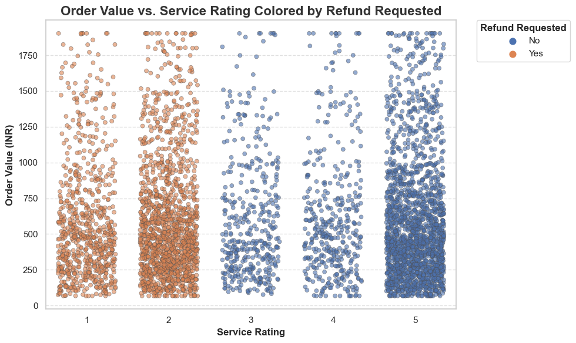

```python
# Re-plot with adjusted legend and improved aesthetics while retaining color scheme
plt.figure(figsize=(10, 6))
sns.set(style="whitegrid")

# Create the strip plot
plot = sns.stripplot(
    data=df,
    x='Service Rating',
    y='Order Value (INR)',
    hue='Refund Requested',
    jitter=0.35,
    alpha=0.6,
    edgecolor='gray',
    linewidth=0.5
)

# Enhance title and axis labels
plt.title('Order Value vs. Service Rating Colored by Refund Requested', fontsize=16, fontweight='bold', color='#333333')
plt.xlabel('Service Rating', fontsize=12, fontweight='semibold')
plt.ylabel('Order Value (INR)', fontsize=12, fontweight='semibold')
plt.xticks(fontsize=11)
plt.yticks(fontsize=11)

# Customize legend and position it outside the plot
handles, labels = plot.get_legend_handles_labels()
custom_labels = ['No', 'Yes']
legend = plt.legend(
    handles=handles,
    labels=custom_labels,
    title='Refund Requested',
    loc='upper left',
    bbox_to_anchor=(1.05, 1),
    borderaxespad=0,
    frameon=True
)
plt.setp(legend.get_title(), fontsize=12, fontweight='bold')
plt.setp(legend.get_texts(), fontsize=11)

# Add horizontal grid lines for better readability
plt.grid(axis='y', linestyle='--', alpha=0.6)
plt.tight_layout()
plt.show()
```

This scatter (strip) plot displays the relationship between **Service Rating** and **Order Value**, segmented by whether a **refund was requested**.

#### Key Observations:

- Refunds are **highly concentrated at lower ratings** (1 and 2), confirming poor service experiences drive refund requests.
- **Higher ratings (4 and 5)** are mostly associated with **no refunds**, indicating positive customer satisfaction.
- Refunds also appear across **all order values**, suggesting **service quality** plays a bigger role than order size in refund decisions.

#### Business Takeaways:

- **Improving service quality** can directly reduce refund rates, especially for low-rated deliveries.
- Targeted follow-ups for orders rated 1 or 2 could **proactively resolve issues** before customers request refunds.
- Combines insights from **transaction value** and **customer perception**, aiding strategic interventions in customer service.

### 3. Delivery Time by Product Category and Refund Requested

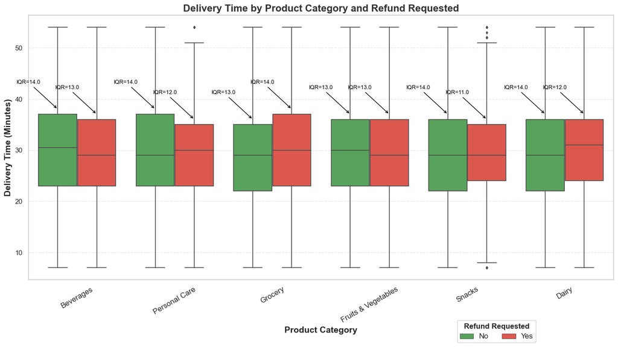

```python
# Set the refund palette
refund_palette = {0: '#4CAF50', 1: '#F44336'}  # Green for No, Red for Yes

# Create the boxplot
plt.figure(figsize=(14, 8))
sns.set(style="whitegrid")

ax = sns.boxplot(
    data=df,
    x='Product Category',
    y='Delivery Time (Minutes)',
    hue='Refund Requested',
    palette=refund_palette,
    linewidth=1.2,
    fliersize=3
)

# Calculate and annotate IQR for each category/refund combo
categories = df['Product Category'].unique()
for i, category in enumerate(categories):
    for refund in [0, 1]:
        subset = df[(df['Product Category'] == category) & (df['Refund Requested'] == refund)]
        if not subset.empty:
            q1 = subset['Delivery Time (Minutes)'].quantile(0.25)
            q3 = subset['Delivery Time (Minutes)'].quantile(0.75)
            iqr = q3 - q1
            x_pos = i + (-0.2 if refund == 0 else 0.2)

            # Annotate IQR with arrow
            ax.annotate(f"IQR={iqr:.1f}",
                        xy=(x_pos, q3 + 1),
                        xytext=(x_pos - 0.3, q3 + 6),
                        arrowprops=dict(arrowstyle='->', color='black'),
                        ha='center', fontsize=9, color='black')

# Customize labels and title
plt.title('Delivery Time by Product Category and Refund Requested', fontsize=16, fontweight='bold', color='#333333')
plt.xlabel('Product Category', fontsize=14, fontweight='semibold')
plt.ylabel('Delivery Time (Minutes)', fontsize=14, fontweight='semibold')
plt.xticks(rotation=30, fontsize=12)
plt.yticks(fontsize=11)

# Adjust and relabel legend to bottom center outside
handles, labels = ax.get_legend_handles_labels()
labels = ['No', 'Yes']
legend = plt.legend(handles=handles, labels=labels, title='Refund Requested', loc='lower center',
                    bbox_to_anchor=(0.8, -0.25), ncol=2, frameon=True)
plt.setp(legend.get_title(), fontsize=12, fontweight='bold')
plt.setp(legend.get_texts(), fontsize=12)

plt.grid(axis='y', linestyle='--', alpha=0.5)
plt.tight_layout()
plt.show()
```

This boxplot compares **delivery time distributions** across different **product categories**, segmented by whether a **refund was requested**. It also annotates the **interquartile range (IQR)** for each group.

#### Business Relevance:

- This plot helps isolate whether **delivery duration** is a key driver for refunds across product lines.
- Uniform IQRs suggest that operational consistency exists; however, attention may be needed in **category-specific quality control** or **communication post-delivery**.

### Additional Visual

### Correlation Heatmap of Numeric Features

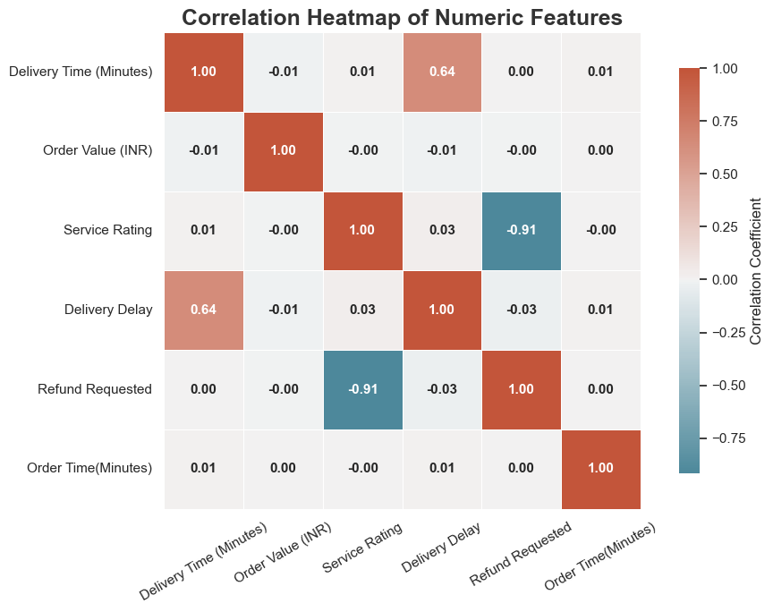

```python
# Select only numeric columns
numeric_df = df.select_dtypes(include=[np.number])

# Compute correlation matrix
corr_matrix = numeric_df.corr()

# Plot heatmap with improved aesthetics
plt.figure(figsize=(10, 7))
sns.set(style="white")

# Define a more visually appealing diverging colormap
cmap = sns.diverging_palette(220, 20, as_cmap=True)

# Create the heatmap
heatmap = sns.heatmap(
    corr_matrix,
    annot=True,
    fmt=".2f",
    cmap=cmap,
    center=0,
    linewidths=0.7,
    square=True,
    cbar_kws={"shrink": .85, "label": "Correlation Coefficient"},
    annot_kws={"size": 11, "weight": "bold"}
)

# Aesthetic titles and layout
plt.title('Correlation Heatmap of Numeric Features', fontsize=18, weight='bold', color='#333333')
plt.xticks(rotation=30, fontsize=11)
plt.yticks(fontsize=11)
plt.tight_layout()
plt.show()
```

This heatmap displays the **pairwise Pearson correlation coefficients** between all numerical features in the dataset, including delivery time, service rating, order value, delivery delay, and refund status.

#### Key Observations:

- **Service Rating and Refund Requested** show a **strong negative correlation (-0.91)**, indicating that **lower service ratings are strongly associated with higher refund requests**. This aligns with intuitive business logic — dissatisfied customers are more likely to request refunds.
- **Delivery Delay and Delivery Time** exhibit a **moderate positive correlation (0.64)**, validating that longer deliveries are more likely to be flagged as delayed — an expected operational insight.
- **Refund Requested and Delivery Delay** show a weak **negative correlation (-0.03)**, suggesting that **delivery delays may not be the primary factor** influencing refund behavior.
- **Order Value** has **almost no correlation** with refunds or delivery performance, implying that customers' decision to refund is **not strongly price-dependent**.

#### Business Relevance:

- These correlations help identify **which factors influence refund behavior** the most, providing guidance for feature selection in predictive modeling (Phase 2).
- The **strong inverse link between service rating and refunds** highlights the need for customer service improvements.
- **Weak correlations among other variables** suggest that a **multivariate analysis** (e.g., classification modeling) is necessary to capture the full complexity of refund drivers.

## Summary & Conclusions

In **Phase 1** of our project, we explored refund behavior in the Indian e-commerce industry using a real-world inspired dataset sourced from Kaggle. Our primary objective was to prepare the data for predictive modeling by performing data cleaning, preprocessing, and exploratory data analysis (EDA).

#### Key Steps:

- **Data Cleaning & Preprocessing**
  - Handled missing values and removed ID-like columns (e.g., Order ID, Customer ID).
  - Converted time-based features into numeric format.
  - Encoded binary variables (e.g., 'Yes' to 1, 'No' to 0).
  - Used percentile-based clamping to treat outliers in key numeric variables.
- **Data Exploration & Visualization**
  - Plotted a total of **11 visualizations** across:
    - **One-variable plots** (Histogram, Boxplots, Count Plots) (4 nos)
    - **Two-variable plots** (Refund vs Platform, Rating vs Refund, Category vs Refund) (3 nos)
    - **Three-variable plots** (e.g., Platform vs Product Category vs Refunds) (3 nos)
    - **Correlation Heatmap of Numeric Features** (1 nos)

#### Next Steps (Phase 2 Preview):

With a clean and well-understood dataset, we are now ready to move into **Phase 2**, where we will:

- Build and evaluate **supervised machine learning models** to predict refund requests.
- Perform **feature selection**, **model tuning**, and **comparison** across classification algorithms.
- Derive **actionable insights** to help platforms reduce refund rates and improve customer satisfaction.

### References

1. Vatsalan, D., Christen, P., & Verykios, V. S. (2013). A taxonomy of privacy-preserving record linkage techniques. *Information Systems*, 38(6), 946–969. https://doi.org/10.1016/j.is.2012.11.005
2. He, H., & Garcia, E. A. (2009). Learning from imbalanced data. *IEEE Transactions on Knowledge and Data Engineering*, 21(9), 1263–1284. https://doi.org/10.1109/TKDE.2008.239
3. Caruana, R., & Niculescu-Mizil, A. (2006). An empirical comparison of supervised learning algorithms. In *Proceedings of the 23rd International Conference on Machine Learning* (pp. 161–168). ACM. https://doi.org/10.1145/1143844.1143865
4. Wang, S., & Yao, X. (2013). Multiclass imbalance problems: Analysis and potential solutions. *IEEE Transactions on Systems, Man, and Cybernetics: Systems*, 42(4), 1119–1130. https://doi.org/10.1109/TSMCB.2012.2187280
5. Chen, T., & Guestrin, C. (2016). XGBoost: A scalable tree boosting system. In *Proceedings of the 22nd ACM SIGKDD International Conference on Knowledge Discovery and Data Mining* (pp. 785–794). https://doi.org/10.1145/2939672.2939785
6. Sun, Y., Wong, A. K. C., & Kamel, M. S. (2009). Classification of imbalanced data: A review. *International Journal of Pattern Recognition and Artificial Intelligence*, 23(4), 687–719. https://doi.org/10.1142/S0218001409007326
7. Buda, M., Maki, A., & Mazurowski, M. A. (2018). A systematic study of the class imbalance problem in convolutional neural networks. *Neural Networks*, 106, 249–259. https://doi.org/10.1016/j.neunet.2018.07.011
8. Quinlan, J. R. (1996). Improved use of continuous attributes in C4.5. *Journal of Artificial Intelligence Research*, 4, 77–90. https://doi.org/10.1613/jair.279
9. Chen, W., Yang, K., Yu, Z., Shi, Y., & Chen, P. (2024). A survey on imbalanced learning: latest research, applications and future directions. Artificial Intelligence Review, 57(6). https://doi.org/10.1007/s10462-024-10759-6
10. Duong, Q. H., Zhou, L., Nguyen, T. V., & Meng, M. (2024). Understanding and Predicting Online Product Return Behavior: An Interpretable Machine Learning Approach. International Journal of Production Economics, 109499–109499. https://doi.org/10.1016/j.ijpe.2024.109499
11. Hayaeian Shirvan, M., Moattar, M. H., & Hosseinzadeh, M. (2025). Deep generative approaches for oversampling in imbalanced data classification problems: A comprehensive review and comparative analysis. Applied Soft Computing, 170, 112677. https://doi.org/10.1016/j.asoc.2024.112677
12. Zhao, Y., Yan, X., Gui, X., Han, S., Sheng, X.-R., Yu, G., Chen, J., Xu, Z., & Zheng, B. (2023). Entire Space Cascade Delayed Feedback Modeling for Effective Conversion Rate Prediction. https://doi.org/10.1145/3583780.3615475
13. Zhu, Y., Li, J., He, J., Quanz, B., & Deshpande, A. (2018). A Local Algorithm for Product Return Prediction in E-Commerce. https://www.ijcai.org/proceedings/2018/0517.pdf
14. Cai, Y., Chen, F., & Zhang, J. (2024). Prediction of After-Sales Behavior in E-Commerce Using Machine Learning Models. Open Journal of Statistics, 14(06), 757–774. https://doi.org/10.4236/ojs.2024.146035